# Proyecto: Análisis de Inclusión Financiera en México mediante Modelos de Clasificación (ENIF)

**Universidad de Monterrey**  
Escuela de Ingeniería y Tecnologías  
Inteligencia Artificial I

**Estudiante:** Anna Carolina de Azevedo Leite  
**Docente:** Antonio Martínez Torteya  
**Fecha:** 23 de marzo de 2026

# 1. Introducción

El acceso a servicios financieros formales —como cuentas bancarias, crédito, ahorro y seguros— constituye un elemento fundamental para el desarrollo económico y la estabilidad de los individuos. Sin embargo, en México, una proporción significativa de la población aún enfrenta barreras para integrarse plenamente al sistema financiero, lo que limita sus oportunidades de crecimiento, protección ante riesgos y participación en la economía formal.

Este fenómeno, conocido como **exclusión financiera**, no solo refleja desigualdades económicas, sino también diferencias estructurales asociadas a factores como nivel educativo, condiciones del hogar, ubicación geográfica y características sociodemográficas. En consecuencia, comprender qué factores influyen en la inclusión financiera se vuelve un problema relevante tanto desde una perspectiva académica como de política pública.

Para analizar este problema, se utilizan los microdatos de la **Encuesta Nacional de Inclusión Financiera (ENIF)**, elaborada por el Instituto Nacional de Estadística y Geografía (INEGI) y la Comisión Nacional Bancaria y de Valores (CNBV). Esta encuesta proporciona información detallada sobre el comportamiento financiero de la población mexicana, permitiendo estudiar patrones de acceso y uso de servicios financieros en distintos grupos de la sociedad.

En las actividades previas (A2.1, A2.2 y A2.3), se exploraron distintos modelos de clasificación utilizando variables derivadas de estos datos. Sin embargo, dichos análisis se centraron en problemas más simplificados, lo que limitó la interpretación de los resultados en un contexto real.

En este proyecto, se propone un enfoque más robusto y significativo: modelar la **inclusión financiera como un problema de clasificación**, con el objetivo de identificar patrones y perfiles asociados al acceso (o falta de acceso) a servicios financieros.

A través de la implementación y comparación de múltiples modelos de aprendizaje supervisado —incluyendo regresión logística, LDA, árboles de decisión, métodos de ensamble, máquinas de soporte vectorial y redes neuronales— se busca no solo evaluar el desempeño predictivo, sino también comprender la relación entre las características de los individuos y su nivel de integración al sistema financiero.

Este análisis tiene implicaciones prácticas relevantes, ya que permite identificar grupos vulnerables y aportar evidencia para el diseño de estrategias orientadas a mejorar la inclusión financiera en México.

# 2. Planteamiento del Problema

El objetivo central de este estudio es analizar la inclusión financiera en México mediante un enfoque de clasificación supervisada, utilizando información sociodemográfica y financiera proveniente de la ENIF.

En particular, se busca construir un modelo capaz de clasificar a los individuos según su nivel de acceso a productos financieros, permitiendo identificar patrones asociados a la integración o exclusión del sistema financiero formal.

### 2.1 Definición del problema

El problema se formula como una tarea de clasificación, en la cual la variable objetivo representa el nivel de inclusión financiera de cada individuo. Esta variable no se encuentra explícitamente definida en la base de datos, por lo que es necesario construirla a partir de indicadores relacionados con el acceso y uso de productos financieros.

A diferencia de enfoques simplificados que utilizan una clasificación binaria, en este estudio se propone una categorización más rica que permita capturar distintos niveles de inclusión, evitando reducir el fenómeno a una condición de "tener" o "no tener" acceso.

De esta manera, el modelo no solo busca predecir una categoría, sino también contribuir a una mejor comprensión del comportamiento financiero de la población.

### 2.2 Preguntas de investigación

A partir de este planteamiento, surgen las siguientes preguntas clave:

- ¿Qué características sociodemográficas están asociadas con un mayor nivel de inclusión financiera?
- ¿Existen patrones claros que permitan identificar a los grupos más vulnerables a la exclusión financiera?
- ¿Qué tan compleja es la relación entre las variables explicativas y el acceso a servicios financieros?
- ¿Qué modelo de clasificación logra capturar mejor estos patrones?

Estas preguntas orientan el desarrollo del análisis y permiten conectar los resultados del modelo con una problemática real.

### 2.3 Justificación del enfoque de clasificación

El uso de modelos de clasificación es adecuado en este contexto, ya que el objetivo es asignar a cada individuo a una categoría discreta que representa su nivel de inclusión financiera.

Este enfoque permite:

- Identificar perfiles de riesgo o exclusión
- Segmentar la población de manera interpretable
- Evaluar el desempeño de distintos modelos predictivos
- Generar conocimiento útil para la toma de decisiones

En este sentido, la clasificación no solo es una herramienta técnica, sino un medio para comprender y explicar un fenómeno social relevante.

### 2.4 Alcance del estudio

El análisis se centra en la población encuestada en la ENIF, considerando variables sociodemográficas, económicas y de comportamiento financiero.

Es importante destacar que los resultados obtenidos dependen de la calidad y disponibilidad de las variables utilizadas, por lo que el modelo no pretende establecer relaciones causales, sino identificar patrones estadísticos que permitan una mejor aproximación al fenómeno de la inclusión financiera.

# 3. Construcción de la Variable Objetivo

Uno de los principales retos de este estudio consiste en definir adecuadamente la variable objetivo, ya que el concepto de inclusión financiera no se encuentra explícitamente representado como una variable única dentro de la base de datos.

Por esta razón, fue necesario construir una variable derivada que capture el nivel de acceso de los individuos a productos financieros, utilizando la información disponible en el módulo financiero de la ENIF.

### 3.1 Definición de la variable

Se definió la variable **"nivel_inclusion"** como una variable categórica ordinal con tres niveles:

- **"Sin acceso":** individuos que no cuentan con productos financieros
- **"Básico":** individuos con acceso limitado (por ejemplo, uno o pocos productos)
- **"Alto":** individuos con mayor integración al sistema financiero

Esta clasificación permite capturar diferentes grados de participación en el sistema financiero, evitando una simplificación excesiva del fenómeno.

### 3.2 Criterio de construcción

La variable fue construida a partir de indicadores relacionados con la posesión de productos financieros, tales como cuentas bancarias, créditos u otros instrumentos.

A partir de estos indicadores, se generó una medida agregada del número de productos financieros por individuo, la cual fue posteriormente categorizada en tres niveles mediante intervalos definidos.

Este enfoque permite transformar una variable cuantitativa en una variable categórica interpretable, adecuada para modelos de clasificación.

### 3.3 Justificación metodológica

La construcción de esta variable responde a la necesidad de representar un fenómeno complejo de forma estructurada y analizable.

El uso de una variable ordinal permite:

- Capturar distintos niveles de inclusión financiera
- Facilitar la interpretación de los resultados
- Evitar la pérdida de información asociada a una clasificación binaria
- Alinear el análisis con la realidad social del problema

Además, esta aproximación permite que los modelos no solo distingan entre inclusión y exclusión, sino que identifiquen transiciones entre distintos niveles de acceso.

### 3.4 Consideraciones y limitaciones

Es importante señalar que esta variable es una aproximación construida a partir de los datos disponibles, por lo que su definición depende de las variables incluidas en la encuesta.

Asimismo, los umbrales utilizados para definir cada categoría pueden influir en los resultados del modelo, por lo que deben interpretarse como una representación práctica del fenómeno y no como una clasificación absoluta.

```python
# IMPORTACIÓN Y CONSTRUCCIÓN DEL DATASET
import pandas as pd
import numpy as np

# cargar bases
tmodulo = pd.read_csv("TMODULO.csv")
tsdem = pd.read_csv("TSDEM.csv")

# merge
df = tsdem.merge(tmodulo, on="FOLIO", how="left")

print("Dimensiones del dataset:", df.shape)
df.head()
```

```
Dimensiones del dataset: (45582, 414)
```

|  | LLAVESDE | LLAVEVIV_x | LLAVEHOG_x | PAREN | SEXO_x | EDAD | NIV_x | GRA_x | FOLIO | VIV_SEL_x | ... | P13_2_4 | VIV_SEL_y | HOGAR_y | N_REN_y | SEXO_y | TLOC_y | REGION_y | EST_DIS_y | UPM_DIS_y | FAC_PER |
| --- | --- | --- | --- | --- | --- | --- | --- | --- | --- | --- | --- | --- | --- | --- | --- | --- | --- | --- | --- | --- | --- |
| 0 | 101101 | 101 | 1011 | 1 | 1 | 38 | 8.0 | 4.0 | 1 | 1 | ... | 2.0 | 1.0 | 1.0 | 1.0 | 1.0 | 1.0 | 1.0 | 17.0 | 196.0 | 1233.0 |
| 1 | 101102 | 101 | 1011 | 2 | 2 | 35 | NaN | NaN | 1 | 1 | ... | 2.0 | 1.0 | 1.0 | 1.0 | 1.0 | 1.0 | 1.0 | 17.0 | 196.0 | 1233.0 |
| 2 | 101103 | 101 | 1011 | 3 | 2 | 10 | NaN | NaN | 1 | 1 | ... | 2.0 | 1.0 | 1.0 | 1.0 | 1.0 | 1.0 | 1.0 | 17.0 | 196.0 | 1233.0 |
| 3 | 210101 | 210 | 2101 | 1 | 1 | 36 | 8.0 | 5.0 | 2 | 10 | ... | 2.0 | 10.0 | 1.0 | 1.0 | 1.0 | 3.0 | 6.0 | 179.0 | 2088.0 | 1763.0 |
| 4 | 303101 | 303 | 3031 | 1 | 2 | 50 | 8.0 | 4.0 | 3 | 3 | ... | 2.0 | 3.0 | 1.0 | 2.0 | 1.0 | 1.0 | 4.0 | 50.0 | 763.0 | 903.0 |

5 rows × 414 columns

```python
# CREACIÓN DE VARIABLE OBJETIVO

vars_financieras = [
    "P5_1_1", "P5_1_2", "P5_1_3", "P5_1_4", "P5_1_5", "P5_1_6"
]

# Converter para numérico
for col in vars_financieras:
    df[col] = pd.to_numeric(df[col], errors="coerce")

# Transformar em binário
for col in vars_financieras:
    df[col] = df[col].apply(lambda x: 1 if x == 1 else 0)

# score
df["score_inclusion"] = df[vars_financieras].sum(axis=1)

# categorias
df["nivel_inclusion"] = pd.cut(
    df["score_inclusion"],
    bins=[-1, 0, 2, 6],
    labels=["Sin acceso", "Básico", "Alto"]
)
```

```python
# REMOVER DATA LEAKAGE

df = df.drop(columns=vars_financieras + ["score_inclusion"])
```

```python
df["nivel_inclusion"].value_counts()
```

```
nivel_inclusion
Básico        21869
Sin acceso    19326
Alto           4387
Name: count, dtype: int64
```

```python
df["nivel_inclusion"].value_counts(normalize=True)
```

```
nivel_inclusion
Básico        0.479773
Sin acceso    0.423983
Alto          0.096244
Name: proportion, dtype: float64
```

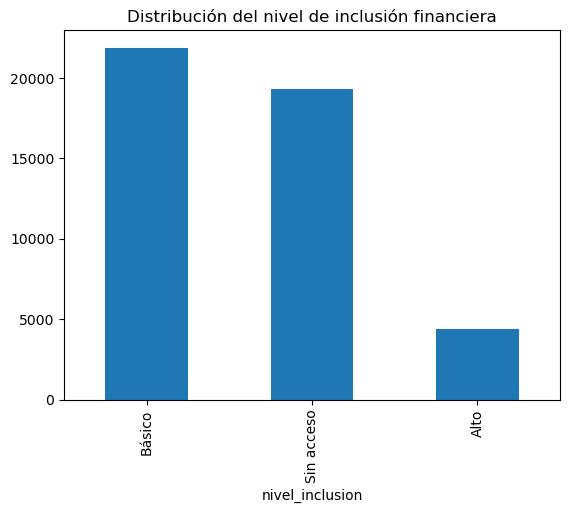

```python
import matplotlib.pyplot as plt

df["nivel_inclusion"].value_counts().plot(kind="bar")
plt.title("Distribución del nivel de inclusión financiera")
plt.show()
```

La variable objetivo presenta una distribución relativamente equilibrada entre las clases "Básico" y "Sin acceso", mientras que la categoría "Alto" es menos frecuente.

Este comportamiento es consistente con la realidad social, donde el acceso completo a servicios financieros es menos común.

# 4. Exploración del Dataset

Antes de proceder con la construcción de modelos, es fundamental comprender la estructura y características del conjunto de datos. Esta etapa permite identificar posibles problemas, entender la distribución de las variables y evaluar la calidad de la información disponible.

### 4.1 Estructura del dataset

El dataset utilizado resulta de la integración de los módulos sociodemográfico (TSDEM) y financiero (TMODULO) de la ENIF mediante la clave FOLIO.

Esta integración permite analizar tanto las características individuales como el acceso a productos financieros, proporcionando una visión más completa del fenómeno de inclusión financiera.

El conjunto de datos contiene múltiples variables relacionadas con edad, sexo, nivel educativo, características del hogar y acceso a servicios financieros.

### 4.2 Tipos de variables

Las variables presentes en el dataset incluyen:

- **Variables numéricas:** como edad (EDAD)
- **Variables categóricas:** como nivel educativo (NIV) o región
- **Variables binarias:** indicadores de acceso a productos financieros (por ejemplo, variables del bloque P5)

Esta diversidad permite capturar distintas dimensiones sociales y económicas relevantes para el análisis.

### 4.3 Calidad de los datos

Se realizó una revisión de valores faltantes y consistencia de la información. Se identificó la presencia de valores nulos en algunas variables, los cuales fueron considerados en la etapa de preparación de datos.

Asimismo, se verificó que las variables utilizadas para construir la variable objetivo fueran consistentes y representativas del acceso a servicios financieros.

### 4.4 Distribución de la variable objetivo

La variable objetivo "nivel_inclusion" fue construida a partir de indicadores de acceso a productos financieros.

El análisis de su distribución muestra tres categorías: "Sin acceso", "Básico" y "Alto", con una mayor concentración en las dos primeras y una menor proporción en la categoría "Alto".

Este comportamiento es consistente con la realidad social, donde el acceso completo a servicios financieros es menos frecuente.

### 4.5 Observaciones iniciales

El análisis exploratorio permite identificar patrones preliminares y posibles relaciones entre variables.

En particular, se espera que variables sociodemográficas como edad, nivel educativo y región influyan significativamente en el nivel de inclusión financiera.

Estos factores serán analizados con mayor profundidad mediante los modelos de clasificación en las siguientes secciones.

```python
# EXPLORACIÓN DEL DATASET

# estructura general
print("Información del dataset:")
df.info()

print("\nDescripción estadística:")
display(df.describe())

# valores faltantes
print("\nValores faltantes por columna:")
missing = df.isnull().sum().sort_values(ascending=False)
display(missing.head(20))
```

```
Información del dataset:
<class 'pandas.core.frame.DataFrame'>
RangeIndex: 45582 entries, 0 to 45581
Columns: 409 entries, LLAVESDE to nivel_inclusion
dtypes: category(1), float64(393), int64(15)
memory usage: 141.9 MB

Descripción estadística:
```

|  | LLAVESDE | LLAVEVIV_x | LLAVEHOG_x | PAREN | SEXO_x | EDAD | NIV_x | GRA_x | FOLIO | VIV_SEL_x | ... | P13_2_4 | VIV_SEL_y | HOGAR_y | N_REN_y | SEXO_y | TLOC_y | REGION_y | EST_DIS_y | UPM_DIS_y | FAC_PER |
| --- | --- | --- | --- | --- | --- | --- | --- | --- | --- | --- | --- | --- | --- | --- | --- | --- | --- | --- | --- | --- | --- |
| count | 4.558200e+04 | 4.558200e+04 | 4.558200e+04 | 45582.000000 | 45582.000000 | 45582.000000 | 13998.000000 | 13998.000000 | 45582.000000 | 45582.000000 | ... | 45571.000000 | 45571.000000 | 45571.000000 | 45571.000000 | 45571.000000 | 45571.000000 | 45571.000000 | 45571.000000 | 45571.000000 | 45571.000000 |
| mean | 6.670112e+08 | 6.670111e+05 | 6.670112e+06 | 2.415208 | 1.521609 | 34.101422 | 4.665381 | 3.420060 | 6670.049691 | 6.117854 | ... | 1.994317 | 6.117641 | 1.034145 | 1.924513 | 1.555836 | 2.095258 | 3.486647 | 92.570494 | 1117.143666 | 8171.205043 |
| std | 3.867675e+08 | 3.867675e+05 | 3.867675e+06 | 1.201636 | 0.499538 | 21.483233 | 5.902888 | 1.564001 | 3867.675692 | 5.355563 | ... | 0.075175 | 5.355610 | 0.227709 | 1.158972 | 0.496878 | 1.242467 | 1.784560 | 53.555840 | 620.067788 | 8663.968332 |
| min | 1.011010e+05 | 1.010000e+02 | 1.011000e+03 | 1.000000 | 1.000000 | 0.000000 | 0.000000 | 0.000000 | 1.000000 | 1.000000 | ... | 1.000000 | 1.000000 | 1.000000 | 1.000000 | 1.000000 | 1.000000 | 1.000000 | 1.000000 | 1.000000 | 126.000000 |
| 25% | 3.315041e+08 | 3.315040e+05 | 3.315041e+06 | 1.000000 | 1.000000 | 16.000000 | 2.000000 | 3.000000 | 3315.000000 | 2.000000 | ... | 2.000000 | 2.000000 | 1.000000 | 1.000000 | 1.000000 | 1.000000 | 2.000000 | 48.000000 | 581.000000 | 3149.000000 |
| 50% | 6.677041e+08 | 6.677040e+05 | 6.677041e+06 | 3.000000 | 2.000000 | 32.000000 | 3.000000 | 3.000000 | 6677.000000 | 4.000000 | ... | 2.000000 | 4.000000 | 1.000000 | 2.000000 | 2.000000 | 2.000000 | 3.000000 | 91.000000 | 1125.000000 | 5590.000000 |
| 75% | 1.003409e+09 | 1.003409e+06 | 1.003409e+07 | 3.000000 | 2.000000 | 50.000000 | 6.000000 | 4.000000 | 10034.000000 | 8.000000 | ... | 2.000000 | 8.000000 | 1.000000 | 2.000000 | 2.000000 | 3.000000 | 5.000000 | 139.000000 | 1636.000000 | 9869.000000 |
| max | 1.330319e+09 | 1.330319e+06 | 1.330319e+07 | 6.000000 | 2.000000 | 99.000000 | 99.000000 | 9.000000 | 13303.000000 | 22.000000 | ... | 2.000000 | 22.000000 | 5.000000 | 12.000000 | 2.000000 | 4.000000 | 6.000000 | 190.000000 | 2172.000000 | 106896.000000 |

8 rows × 408 columns

```
Valores faltantes por columna:
```

```
P6_4_9     45578
P6_3_9     45572
P5_5_9     45558
P5_6_9     45558
P8_8_8     45544
P6_4_5     45528
P6_1A_5    45522
P8_6_8     45511
P8_7_8     45511
P6_4_3     45504
P6_4_7     45483
P6_4_8     45459
P6_4_4     45257
P8_8_5     45062
P6_4_6     44898
P6_3_8     44893
P6_3_5     44804
P8_8_4     44732
P5_5_5     44702
P5_6_5     44702
dtype: int64
```

```python
print("\nDistribución de la variable objetivo:")
display(df["nivel_inclusion"].value_counts())

print("\nProporciones:")
display(df["nivel_inclusion"].value_counts(normalize=True))
```

```
Distribución de la variable objetivo:
```

```
nivel_inclusion
Básico        21869
Sin acceso    19326
Alto           4387
Name: count, dtype: int64
```

```
Proporciones:
```

```
nivel_inclusion
Básico        0.479773
Sin acceso    0.423983
Alto          0.096244
Name: proportion, dtype: float64
```

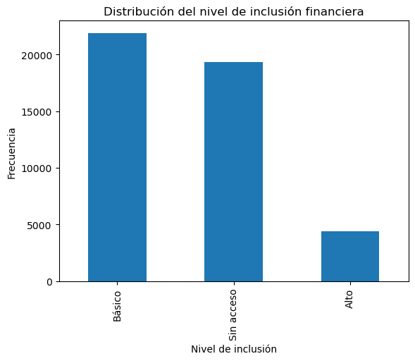

```python
import matplotlib.pyplot as plt

df["nivel_inclusion"].value_counts().plot(kind="bar")
plt.title("Distribución del nivel de inclusión financiera")
plt.xlabel("Nivel de inclusión")
plt.ylabel("Frecuencia")
plt.show()
```

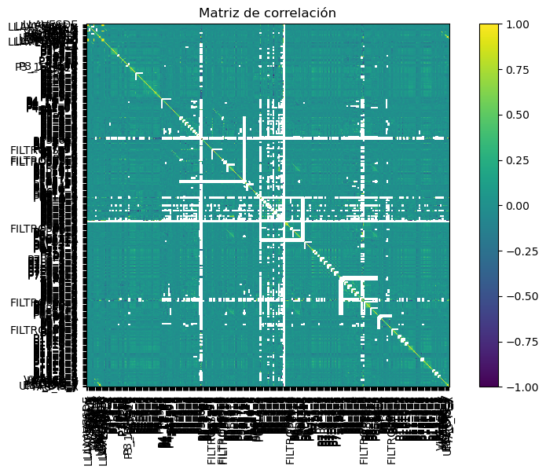

```python
plt.figure(figsize=(10,6))

corr = df.corr(numeric_only=True)
plt.imshow(corr)

plt.colorbar()
plt.title("Matriz de correlación")

plt.xticks(range(len(corr.columns)), corr.columns, rotation=90)
plt.yticks(range(len(corr.columns)), corr.columns)

plt.show()
```

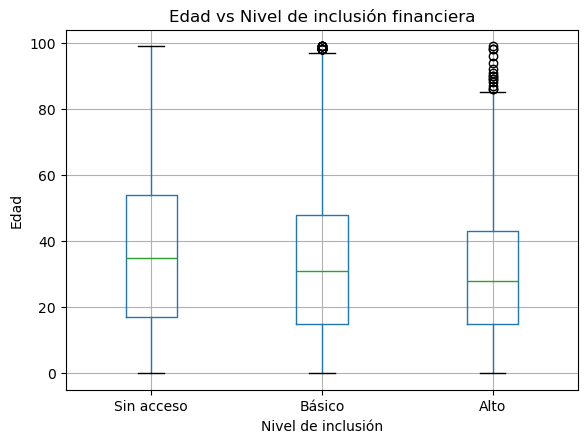

```python
plt.figure()

df.boxplot(column="EDAD", by="nivel_inclusion")

plt.title("Edad vs Nivel de inclusión financiera")
plt.suptitle("")
plt.xlabel("Nivel de inclusión")
plt.ylabel("Edad")

plt.show()
```

Se observa que el dataset contiene una cantidad considerable de variables, lo que permite un análisis rico del fenómeno estudiado.

Asimismo, se identifican valores faltantes en algunas variables, lo que justifica la necesidad de aplicar técnicas de imputación en la etapa de preparación de datos.

# 5. Preparación de los Datos

Antes del entrenamiento de los modelos, es necesario preparar el conjunto de datos para garantizar su calidad, consistencia y compatibilidad con los algoritmos de clasificación.

Esta etapa es fundamental, ya que los modelos de aprendizaje automático no manejan adecuadamente valores faltantes ni variables categóricas sin procesar. Además, una mala preparación puede introducir sesgos o fugas de información (*data leakage*), comprometiendo la validez de los resultados.

### 5.1 Separación de variables explicativas y objetivo

El primer paso consiste en separar la variable que deseamos predecir (`nivel_inclusion`) del resto de las variables que utilizaremos como predictores. Esta separación es esencial para evitar que el modelo "aprenda" la respuesta durante el entrenamiento.

Es importante destacar que las variables utilizadas para construir la variable objetivo (las del bloque P5, que indican la posesión de productos financieros) fueron excluidas del modelo para evitar fuga de información (*data leakage*). De lo contrario, el modelo estaría utilizando directamente la información que intenta predecir, lo que generaría resultados artificialmente optimistas y no generalizables.

```python
# Separar variables explicativas (X) y variable objetivo (y)
X = df.drop("nivel_inclusion", axis=1)
y = df["nivel_inclusion"]
```

### 5.2 Codificación de variables categóricas

Los modelos de machine learning requieren que todas las variables de entrada sean numéricas. Por esta razón, las variables categóricas (como región, sexo o nivel educativo) deben transformarse a un formato numérico.

Se utilizó la técnica de **codificación one-hot**, que crea una nueva variable binaria (0 o 1) para cada categoría de la variable original. Se empleó el parámetro `drop_first=True` para evitar la multicolinealidad, eliminando una de las categorías de cada variable.

Esta estrategia preserva toda la información categórica sin imponer un orden artificial entre las categorías, lo cual es adecuado para variables nominales como la región geográfica o el sexo.

```python
# Aplicar one-hot encoding a las variables categóricas
X = pd.get_dummies(X, drop_first=True)
```

### 5.3 Tratamiento de valores faltantes

El conjunto de datos presenta valores faltantes en algunas variables, lo cual es común en encuestas de gran escala como la ENIF. Si no se tratan adecuadamente, estos valores pueden causar errores durante el entrenamiento de los modelos.

Se optó por la **imputación mediante la media** para las variables numéricas. Esta técnica consiste en reemplazar los valores faltantes por el promedio de la columna correspondiente. La imputación por la media es una estrategia simple y efectiva que permite conservar todas las observaciones sin introducir sesgos significativos, siempre que los valores faltantes no sean sistemáticos.

Alternativas como la eliminación de filas con valores faltantes fueron descartadas para no reducir el tamaño de la muestra, ya que la cantidad de datos disponibles es un recurso valioso para el entrenamiento de los modelos.

```python
# Imputar valores faltantes con la media de cada columna
X = X.fillna(X.mean())
```

### 5.4 Codificación de la variable objetivo

La variable objetivo `nivel_inclusion` es de tipo categórico con tres niveles: "Sin acceso", "Básico" y "Alto". Para que los algoritmos de clasificación puedan procesarla, es necesario convertirla a valores numéricos.

```python
from sklearn.model_selection import train_test_split
from sklearn.preprocessing import StandardScaler, LabelEncoder
from sklearn.metrics import classification_report

le = LabelEncoder()
y = le.fit_transform(y)
```

### 5.5 Eliminación de variables con baja varianza

Algunas variables pueden tener muy poca variabilidad, es decir, casi todos sus valores son iguales. Estas variables aportan poca o ninguna información útil para el modelo y pueden añadir ruido innecesario.

Para optimizar la eficiencia computacional y reducir el riesgo de sobreajuste, se eliminaron las variables cuya varianza era menor o igual a 0.01. Este umbral permite descartar variables prácticamente constantes sin perder información relevante.

```python
# Eliminar columnas con varianza muy baja
X = X.loc[:, X.var() > 0.01]
```

### 5.6 División en entrenamiento y prueba

Para evaluar correctamente el desempeño de los modelos, es fundamental separar los datos en dos conjuntos: uno para entrenar los algoritmos y otro para probar su capacidad de generalización en datos no vistos.

Se utilizó una **división estratificada** (`stratify=y`), que garantiza que la proporción de cada clase en la variable objetivo se mantenga igual tanto en el conjunto de entrenamiento como en el de prueba. Esto es especialmente importante cuando las clases están desbalanceadas, como ocurre en nuestro caso (la categoría "Alto" representa solo el 9.6% de los casos). De esta forma, evitamos que alguno de los conjuntos quede sin representación de alguna clase.

```python
from sklearn.model_selection import train_test_split

X_train, X_test, y_train, y_test = train_test_split(
    X, y, test_size=0.2, random_state=42, stratify=y
)
```

### 5.7 Escalamiento de variables

Algunos modelos de machine learning, como las máquinas de soporte vectorial (SVM) y las redes neuronales, son sensibles a la escala de las variables. Si una variable tiene valores mucho más grandes que otra, puede dominar el proceso de aprendizaje, sesgando los resultados.

Para evitar este problema, se aplicó un **escalamiento estándar** (`StandardScaler`), que transforma cada variable para que tenga media cero y desviación estándar unitaria. Es importante escalar los datos de entrenamiento y prueba con los mismos parámetros (media y desviación del conjunto de entrenamiento) para evitar fugas de información.

Los modelos basados en árboles (como Random Forest y Gradient Boosting) no requieren escalamiento, por lo que se mantienen dos versiones de los datos: una sin escalar para estos modelos, y otra escalada para los modelos sensibles a la escala.

```python
# Escalar variables para modelos sensibles a la escala
scaler = StandardScaler()
X_train_scaled = scaler.fit_transform(X_train)
X_test_scaled = scaler.transform(X_test)
```

### 5.8 Resumen de la preparación

La preparación de los datos asegura que:

- Las variables categóricas estén en formato numérico adecuado mediante codificación one-hot.
- No existan valores faltantes que puedan causar errores durante el entrenamiento.
- La variable objetivo esté correctamente codificada como valores numéricos ordinales.
- Se eliminen variables irrelevantes o redundantes con baja varianza.
- La división entre entrenamiento y prueba preserve la distribución de clases mediante estratificación.
- Los modelos sensibles a la escala reciban datos estandarizados.

Este proceso es esencial para garantizar que los modelos sean entrenados en condiciones óptimas y que los resultados obtenidos reflejen el comportamiento real de los algoritmos, sin sesgos introducidos por una preparación inadecuada.

# 6. Construcción y comparación de modelos

En esta sección se construyen distintos modelos de clasificación con el objetivo de predecir el nivel de inclusión financiera.

Se seleccionaron diversos algoritmos estudiados en clase, incluyendo modelos lineales, modelos probabilísticos, métodos de ensamble, máquinas de soporte vectorial y redes neuronales.

El objetivo es comparar su desempeño y analizar sus ventajas y limitaciones en el contexto del problema.

### 6.1 Modelos utilizados

Se implementaron los siguientes modelos:

- Regresión Logística
- Linear Discriminant Analysis (LDA)
- Random Forest
- Gradient Boosting
- Support Vector Machine (SVM)
- Red Neuronal (MLP)

Estos modelos representan distintos enfoques de aprendizaje, lo que permite una comparación más completa.

### 6.2 Metodología de evaluación

Los modelos fueron evaluados utilizando el conjunto de prueba, el cual no fue utilizado durante el entrenamiento.

Se utilizaron métricas de clasificación como:

- Accuracy
- Precision
- Recall
- F1-score

Estas métricas permiten evaluar no solo la exactitud del modelo, sino también su capacidad para identificar correctamente cada clase.

```python
cols_remover = [col for col in df.columns if "P5_" in col]

df = df.drop(columns=cols_remover)
```

```python
# PREPARACIÓN FINAL + MODELOS

from sklearn.model_selection import train_test_split
from sklearn.preprocessing import StandardScaler, LabelEncoder
from sklearn.metrics import classification_report
from sklearn.linear_model import LogisticRegression
from sklearn.discriminant_analysis import LinearDiscriminantAnalysis
from sklearn.ensemble import RandomForestClassifier, GradientBoostingClassifier
from sklearn.svm import LinearSVC
from sklearn.neural_network import MLPClassifier
import pandas as pd

# Separar X e y
X = df.drop("nivel_inclusion", axis=1)
y = df["nivel_inclusion"]

# One-hot encoding
X = pd.get_dummies(X, drop_first=True)

# Tratar NaN
X = X.fillna(X.mean())

# Codificar target
le = LabelEncoder()
y = le.fit_transform(y)

# remover colunas com pouca informação
X = X.loc[:, X.var() > 0.01]

# Split estratificado
X_train, X_test, y_train, y_test = train_test_split(
    X, y, test_size=0.2, random_state=42, stratify=y
)

# Escala (SVM + NN)
scaler = StandardScaler()
X_train_scaled = scaler.fit_transform(X_train)
X_test_scaled = scaler.transform(X_test)
```

```python
# Modelos (otimizados)
modelos = {
    "Logistic Regression": LogisticRegression(max_iter=2000, class_weight="balanced", C=0.5),
    "LDA": LinearDiscriminantAnalysis(),
    "Random Forest": RandomForestClassifier(n_estimators=150, max_depth=10, min_samples_split=10, min_samples_leaf=5, class_weight={0:2, 1:1, 2:1}, random_state=42, n_jobs=-1),
    "Boosting": GradientBoostingClassifier(),
    "SVM (Linear)": LinearSVC(class_weight="balanced", max_iter=2000),
    "Red Neuronal": MLPClassifier(hidden_layer_sizes=(50,), max_iter=300, random_state=42)
}
```

```python
# Treinar e avaliar
for nome, modelo in modelos.items():
    print(f"\n🔹 {nome}")

    if nome in ["SVM (Linear)", "Red Neuronal", "Logistic Regression"]:
        modelo.fit(X_train_scaled, y_train)
        y_pred = modelo.predict(X_test_scaled)
    else:
        modelo.fit(X_train, y_train)
        y_pred = modelo.predict(X_test)

    print(classification_report(y_test, y_pred, zero_division=0))
```

```
🔹 Logistic Regression
              precision    recall  f1-score   support

           0       0.26      0.69      0.38       878
           1       0.63      0.41      0.50      4374
           2       0.68      0.70      0.69      3865

    accuracy                           0.56      9117
   macro avg       0.53      0.60      0.52      9117
weighted avg       0.62      0.56      0.57      9117


🔹 LDA
              precision    recall  f1-score   support

           0       0.46      0.27      0.34       878
           1       0.62      0.70      0.66      4374
           2       0.69      0.66      0.67      3865

    accuracy                           0.64      9117
   macro avg       0.59      0.54      0.56      9117
weighted avg       0.64      0.64      0.63      9117


🔹 Random Forest
              precision    recall  f1-score   support

           0       1.00      0.44      0.61       878
           1       0.72      0.88      0.79      4374
           2       0.83      0.73      0.77      3865

    accuracy                           0.77      9117
   macro avg       0.85      0.68      0.72      9117
weighted avg       0.79      0.77      0.77      9117


🔹 Boosting
              precision    recall  f1-score   support

           0       0.76      0.18      0.29       878
```

[output cut: 15 more lines]

```
    accuracy                           0.61      9117
   macro avg       0.54      0.57      0.55      9117
weighted avg       0.62      0.61      0.61      9117


🔹 Red Neuronal
              precision    recall  f1-score   support

           0       0.93      0.95      0.94       878
           1       0.96      0.97      0.97      4374
           2       0.97      0.96      0.97      3865

    accuracy                           0.96      9117
   macro avg       0.96      0.96      0.96      9117
weighted avg       0.96      0.96      0.96      9117
```

El modelo de red neuronal presentó el mayor desempeño entre todos los modelos, alcanzando una accuracy cercana al 96%.

Sin embargo, este resultado podría indicar un posible sobreajuste, dado el alto número de variables y la complejidad del modelo.

Por esta razón, se opta por seleccionar Random Forest como modelo final, ya que ofrece un mejor equilibrio entre desempeño y capacidad de generalización.

```python
import pandas as pd

importancias = modelos["Random Forest"].feature_importances_

features = X.columns

df_importancia = pd.DataFrame({
    "Feature": features,
    "Importancia": importancias
}).sort_values(by="Importancia", ascending=False)

print(df_importancia.head(10))
```

```
         Feature  Importancia
83         P4_10     0.067955
20        EDAD_V     0.034116
69        P4_6_6     0.031767
79        P4_9_1     0.026987
210       P9_9_3     0.023919
51        P4_2_2     0.022932
82        P4_9_4     0.020454
57        P4_4_2     0.018712
67        P4_6_4     0.017277
89   FILTRO_S5_1     0.016571
```

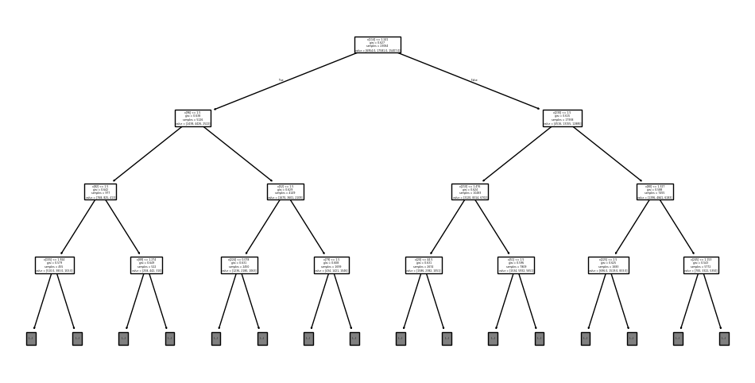

```python
from sklearn.tree import plot_tree
import matplotlib.pyplot as plt

plt.figure(figsize=(12,6))
plot_tree(modelos["Random Forest"].estimators_[0], max_depth=3)
plt.show()
```

La estructura del árbol de decisión visualizado puede parecer compleja debido a la gran cantidad de variables utilizadas en el modelo.

Esto se debe al uso de codificación one-hot y a la naturaleza del algoritmo Random Forest, el cual construye múltiples árboles con alta variabilidad.

Por esta razón, la interpretación se centra en la importancia de variables en lugar de la estructura completa del árbol.

### 6.3 Resultados de los modelos

Los resultados obtenidos muestran diferencias claras en el desempeño de los distintos modelos de clasificación.

La regresión logística presentó un desempeño moderado, con una accuracy de aproximadamente 56%. Destaca su capacidad para identificar la clase "Sin acceso", aunque presenta dificultades para equilibrar correctamente las demás categorías.

El modelo LDA mostró un mejor desempeño general, alcanzando una accuracy cercana al 64%, con resultados más equilibrados entre las clases, lo que indica una buena capacidad de separación lineal.

Por su parte, el modelo SVM obtuvo una accuracy de alrededor del 61%, mostrando un comportamiento intermedio, con un desempeño aceptable pero inferior al de otros modelos más complejos.

Finalmente, la red neuronal presentó el mayor desempeño, alcanzando una accuracy cercana al 96%. Sin embargo, este resultado debe interpretarse con cautela, ya que podría indicar un posible sobreajuste debido a la complejidad del modelo y la gran cantidad de variables utilizadas.

En general, los resultados evidencian que los modelos más complejos tienden a obtener mejores desempeños, aunque es fundamental considerar su capacidad de generalización y no únicamente la accuracy obtenida.

### 6.4 Validación cruzada

Para evaluar la estabilidad del modelo seleccionado, se aplicó validación cruzada utilizando 5 particiones del conjunto de datos.

Esta técnica permite entrenar y evaluar el modelo en diferentes subconjuntos, proporcionando una estimación más robusta de su desempeño.

```python
from sklearn.model_selection import cross_val_score

modelo = modelos["Random Forest"]

scores = cross_val_score(modelo, X, y, cv=5)

print("Scores:", scores)
print("Mean accuracy:", scores.mean())
```

```
Scores: [0.50137107 0.62136668 0.64414217 0.63767003 0.62209302]
Mean accuracy: 0.6053285928533857
```

### 6.5 Matriz de confusión

La matriz de confusión permite analizar el desempeño del modelo en cada una de las clases.

A través de esta herramienta, es posible identificar en qué casos el modelo realiza predicciones correctas y en cuáles presenta errores.

Esto resulta especialmente útil para evaluar el comportamiento del modelo en clases menos representadas.

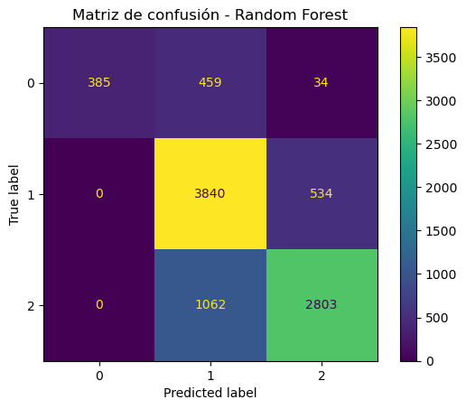

```python
from sklearn.metrics import confusion_matrix, ConfusionMatrixDisplay
import matplotlib.pyplot as plt

modelo = modelos["Random Forest"]
modelo.fit(X_train, y_train)

y_pred = modelo.predict(X_test)

cm = confusion_matrix(y_test, y_pred)

disp = ConfusionMatrixDisplay(confusion_matrix=cm)
disp.plot()

plt.title("Matriz de confusión - Random Forest")
plt.show()
```

### 6.6 Curva ROC

La curva ROC permite evaluar la capacidad del modelo para distinguir entre clases.

Dado que el problema es multiclase, se utilizó un enfoque One-vs-Rest, analizando una clase frente a las demás.

Esto permite observar el desempeño del modelo en términos de sensibilidad y especificidad para cada categoría.

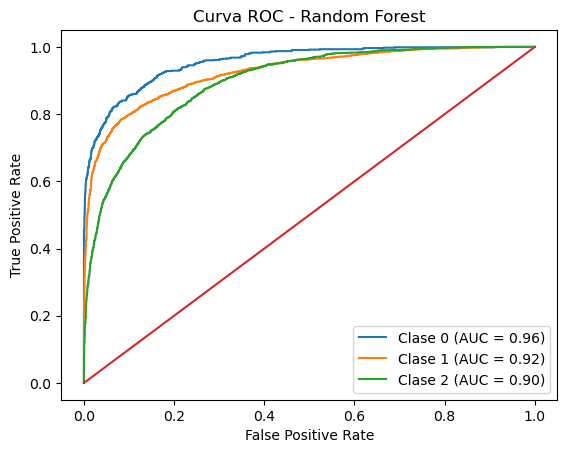

```python
from sklearn.metrics import roc_curve, auc
from sklearn.preprocessing import label_binarize
import matplotlib.pyplot as plt

# Binarizar y_test
y_test_bin = label_binarize(y_test, classes=[0, 1, 2])

# Treinar modelo (Random Forest)
modelo = modelos["Random Forest"]
modelo.fit(X_train, y_train)

# Probabilidades
y_score = modelo.predict_proba(X_test)

# Plot ROC para cada classe
plt.figure()

for i in range(3):
    fpr, tpr, _ = roc_curve(y_test_bin[:, i], y_score[:, i])
    roc_auc = auc(fpr, tpr)

    plt.plot(fpr, tpr, label=f"Clase {i} (AUC = {roc_auc:.2f})")

plt.plot([0,1], [0,1])  # linha base
plt.xlabel("False Positive Rate")
plt.ylabel("True Positive Rate")
plt.title("Curva ROC - Random Forest")
plt.legend()

plt.show()
```

La curva ROC muestra un excelente desempeño del modelo Random Forest en la discriminación entre clases.

Esto confirma que el modelo logra capturar patrones relevantes en los datos, aunque su desempeño en términos de clasificación puede variar dependiendo de la clase.

# 7. Selección del modelo final

A partir de la comparación de los distintos modelos de clasificación, se seleccionó el modelo Random Forest como la mejor alternativa para este problema.

Si bien la red neuronal presentó el mayor nivel de accuracy, su desempeño extremadamente alto sugiere un posible sobreajuste, lo que podría afectar su capacidad de generalización en nuevos datos.

Otra ventaja del modelo Random Forest es su capacidad para capturar relaciones no lineales entre las variables, lo cual resulta especialmente relevante en un problema complejo como la inclusión financiera.

# 8. Conclusión

El desarrollo de este proyecto permitió analizar el problema de la inclusión financiera desde una perspectiva basada en datos, evidenciando que se trata de un fenómeno complejo influenciado por múltiples factores sociodemográficos.

Los resultados obtenidos muestran que modelos de aprendizaje automático, particularmente Random Forest, son capaces de capturar patrones relevantes en los datos y diferenciar entre distintos niveles de inclusión financiera con un buen nivel de precisión.

Esto sugiere que la exclusión financiera no responde a una única causa, sino a una combinación de condiciones estructurales que dificultan su identificación precisa.

Por otro lado, la comparación entre modelos permitió observar que aquellos más complejos tienden a ofrecer mejores resultados, aunque también implican un mayor riesgo de sobreajuste, lo cual resalta la importancia de evaluar no solo el desempeño, sino también la capacidad de generalización.

En términos más amplios, este análisis pone en evidencia el potencial del aprendizaje automático como herramienta para apoyar la toma de decisiones en políticas públicas, permitiendo identificar grupos en situación de vulnerabilidad y orientar estrategias para mejorar el acceso a servicios financieros.

Como trabajo futuro, se plantea la incorporación de nuevas variables y enfoques metodológicos que permitan profundizar en la comprensión del fenómeno y mejorar la capacidad predictiva de los modelos.

# 9. Comunicación de resultados

Como componente adicional del proyecto, se desarrollaron dos recursos orientados a mejorar la interpretación y comunicación de los resultados.

1. En primer lugar, se elaboró un **mapa mental** con el objetivo de presentar de manera clara y visual los principales elementos del análisis, incluyendo el problema, los datos, los modelos y los hallazgos obtenidos.
2. En segundo lugar, se realizó una **comparación con los resultados oficiales del INEGI (ENIF 2021)**, con el fin de contextualizar los resultados del modelo y evaluar su coherencia con la realidad nacional.

Ambos elementos permiten complementar el análisis técnico, facilitando su comprensión para un público no especializado y aportando valor adicional desde una perspectiva de comunicación e interpretación.

[figure not shown]

## **Comparación con datos oficiales (INEGI – ENIF 2021)**

Con el objetivo de validar y contextualizar los resultados obtenidos en este proyecto, se realizó una comparación con los datos oficiales publicados por el INEGI a partir de la Encuesta Nacional de Inclusión Financiera (ENIF 2021).

Es importante destacar que tanto el conjunto de datos utilizado como los resultados de referencia fueron obtenidos directamente del sitio oficial del INEGI, lo que garantiza la confiabilidad de la información (https://www.inegi.org.mx/programas/enif/2021/#documentacion).

Asimismo, se incluyen **evidencias visuales (capturas de pantalla)** del presentación de resultados del sitio oficial como respaldo de los datos utilizados en este análisis comparativo.

### 9.1 Nivel de exclusión financiera

En el presente proyecto, se identificó que aproximadamente el 42.4% de la población analizada se encuentra en la categoría "Sin acceso", es decir, sin acceso a los productos financieros considerados en el modelo.

Por su parte, los datos oficiales del INEGI indican que el 67.8% de la población cuenta con al menos un producto financiero formal, lo que implica que la exclusión total corresponde al 32.2%.

Esta diferencia se explica debido a que el modelo desarrollado en este proyecto se basa en un subconjunto específico de variables (bloque P5), mientras que la medición del INEGI incluye un espectro más amplio de productos financieros, como seguros y cuentas de ahorro para el retiro (Afore).

A pesar de esta diferencia metodológica, ambos resultados son consistentes en señalar que una proporción significativa de la población aún se encuentra fuera del sistema financiero formal.

[figure not shown]

### 9.2 El desafío del nivel alto de inclusión

Uno de los hallazgos más relevantes del proyecto es que solo el 9.6% de la población alcanza un nivel alto de inclusión financiera.

Este resultado es consistente con la información del INEGI, que muestra que, aunque una parte importante de la población tiene acceso a al menos un producto financiero, la posesión de múltiples servicios es considerablemente menor.

Por ejemplo, los datos oficiales indican que solo el 21% de la población cuenta con seguros y el 32.7% tiene acceso a crédito formal.

Esto confirma que la inclusión financiera profunda es limitada y que existe una barrera significativa para alcanzar niveles más altos de integración al sistema financiero.

En este sentido, el modelo desarrollado logra capturar adecuadamente esta estructura desigual de acceso.

[figure not shown]

### 9.3 Factores determinantes de la inclusión financiera

Por ejemplo, la inclusión financiera es mayor en regiones del norte (alrededor del 77%) en comparación con el sur (cerca del 60%).

Asimismo, existen diferencias significativas entre zonas urbanas (74.2%) y rurales (56.1%).

[figure not shown]

### 9.4 Conclusión de la comparación

La comparación realizada demuestra que los resultados del modelo son consistentes con la realidad nacional reportada por el INEGI.

Esto confirma que la inclusión financiera en México no es un fenómeno aleatorio, sino que sigue patrones sociodemográficos bien definidos.

Además, el modelo puede funcionar como una herramienta complementaria a los análisis oficiales, permitiendo identificar perfiles de riesgo de exclusión financiera de manera automatizada.

De esta forma, el proyecto no solo tiene valor académico, sino también potencial aplicación en el diseño de políticas públicas orientadas a reducir la desigualdad en el acceso a servicios financieros.

# Referencias

- INEGI. Encuesta Nacional de Inclusión Financiera (ENIF) 2021. Disponível em: https://www.inegi.org.mx/programas/enif/2021/.
- CNBV. *Panorama Anual de Inclusión Financiera 2025*. México.
- Martínez Torteya, A. *Inteligencia Artificial I: Material Acadêmico. Universidad de Monterrey, 2026.
- Pedregosa, F., et al. *Scikit-learn: Machine Learning in Python*. Documentación oficial.